```python
import requests
import numpy as np
import pandas as pd
from bs4 import BeautifulSoup
from bs4 import Comment
import sqlite3
import seaborn as sns
import matplotlib.pyplot as plt
import sklearn
from sklearn.linear_model import LinearRegression
from sklearn.metrics import mean_squared_error
from sklearn.preprocessing import RobustScaler, LabelEncoder, StandardScaler
from sklearn import linear_model
from sklearn.svm import SVR
```

# NFL Passer Rating Analysis

# Introduction

A big part of a team's ability to succeed in the National Football League is how good of a quarterback the team has. Many say that quarterback is the most important position, and although a team can succeed without a good quarterback, it is by far the biggest determination of a team's success. There are many metrics used to measure quarterback statistics, but passer rating is the most commonly used one. Passer rating is calculated in the NFL by using a player's passing attempts, completions, yards, touchdowns, and interceptions on a scale from 0 to 158.3.

This is a link to the Wikipedia page on passer rating: https://en.wikipedia.org/wiki/Passer_rating#:~:text=Passer%20rating%20

Within this project, I will analyze the success of teams in terms of their Win-Loss percentage as an effect of the team's passer rating, displaying the importance of the quarterback position on the success of a team from the year 2003-2020.

# Getting Data

The links to the website the data is pulled from for each year is below, stored in a variable titled "url20XX" for the year the data is for. For a portion of the years a tie did not take place and therefore the website dropped the tie column for that year instead of having an entire row of zeroes for the tie column, so I separated the URLs into ties and no ties.

```python
#Tie occured
url2008="https://www.pro-football-reference.com/years/2008/index.htm"
url2012="https://www.pro-football-reference.com/years/2012/index.htm"
url2013="https://www.pro-football-reference.com/years/2013/index.htm"
url2014="https://www.pro-football-reference.com/years/2014/index.htm"
url2016="https://www.pro-football-reference.com/years/2016/index.htm"
url2018="https://www.pro-football-reference.com/years/2018/index.htm"
url2019="https://www.pro-football-reference.com/years/2019/index.htm"
url2020="https://www.pro-football-reference.com/years/2020/index.htm"
#No Ties Occured
url2003="https://www.pro-football-reference.com/years/2003/index.htm"
url2004="https://www.pro-football-reference.com/years/2004/index.htm"
url2005="https://www.pro-football-reference.com/years/2005/index.htm"
url2006="https://www.pro-football-reference.com/years/2006/index.htm"
url2007="https://www.pro-football-reference.com/years/2007/index.htm"
url2009="https://www.pro-football-reference.com/years/2009/index.htm"
url2010="https://www.pro-football-reference.com/years/2010/index.htm"
url2011="https://www.pro-football-reference.com/years/2011/index.htm"
url2015="https://www.pro-football-reference.com/years/2015/index.htm"
url2017="https://www.pro-football-reference.com/years/2017/index.htm"
```

Below is a function used for each year between 2003 and 2020, with a parameter for the link to the year, whether a tie took place that year, and the year. I then used the requests package to get the URL and the beautiful soup package to give the html of the site. I used the find function to get the table for the AFC and then put all of the table information into an array named data. If the year had a tie column I then put it into a dataframe for the AFC otherwise I put every column present and a tie column full of zeroes into a dataframe. I then dropped the rows and columns that were not used and re-indexed after dropping them. I repeated the process for the table for the NFC, putting it into a dataframe for the NFC at the end in the same fashion.

I then created a dataframe that combined the two leagues and converted the win loss percentage to a float for later calculations. I also sorted by that column and re-indexed based on it, and created a year column that the parameter is used for, finally re-ordering the columns. The last step was to use the comment package in order to get the data for the last table, which is the one containing the passer rating data. I put it into a dataframe and dropped every column except the team and rate so that I could then merge the dataframe with the records with this one to have the rates as well. I finally sorted by rate and returned that year's dataframe.

```python
def getyeardata(u, m, y):
    response = requests.get(u)
    soup = BeautifulSoup(response.text, "html.parser")
    soup.prettify()
    htmltable = soup.find(id="AFC")
    data = []
    tablebody = htmltable.find('tbody')
    rows = tablebody.find_all('tr')
    for singlerow in rows:
        names = singlerow.find_all('a')
        names = [element.text.strip() for element in names]
        cols = singlerow.find_all('td')
        cols = [element.text.strip() for element in cols]
        cols.append([element for element in names])
        data.append([element for element in cols])
    if m == 1:
        afcdata = pd.DataFrame(data, columns=['W', 'L', 'T', 'W-L%', 'PF', 'PA', 'PD', 'MoV', 'SoS', 'SRS', 'OSRS', 'DSRS', 'Team'])
    else:
        afcdata = pd.DataFrame(data, columns=['W', 'L', 'W-L%', 'PF', 'PA', 'PD', 'MoV', 'SoS', 'SRS', 'OSRS', 'DSRS', 'Team'])
        afcdata = afcdata.assign(T='0')
    afcdata = afcdata.drop([0, 5, 10, 15])
    afcdata = afcdata.drop(columns=['PF', 'PA', 'PD', 'MoV', 'SoS', 'SRS', 'OSRS', 'DSRS'])
    afcdata.index = range(16)
    htmltable = soup.find(id="NFC")
    data = []
    tablebody = htmltable.find('tbody')
    rows = tablebody.find_all('tr')
    for singlerow in rows:
        names = singlerow.find_all('a')
        names = [element.text.strip() for element in names]
        cols = singlerow.find_all('td')
        cols = [element.text.strip() for element in cols]
        cols.append([element for element in names])
        data.append([element for element in cols])
    if m == 1:
        nfcdata = pd.DataFrame(data, columns=['W', 'L', 'T', 'W-L%', 'PF', 'PA', 'PD', 'MoV', 'SoS', 'SRS', 'OSRS', 'DSRS', 'Team'])
    else:
        nfcdata = pd.DataFrame(data, columns=['W', 'L', 'W-L%', 'PF', 'PA', 'PD', 'MoV', 'SoS', 'SRS', 'OSRS', 'DSRS', 'Team'])
        nfcdata = nfcdata.assign(T='0')
    nfcdata = nfcdata.drop([0, 5, 10, 15])
    nfcdata = nfcdata.drop(columns=['PF', 'PA', 'PD', 'MoV', 'SoS', 'SRS', 'OSRS', 'DSRS'])
    nfcdata.index = range(16, 32)
    frames = [afcdata, nfcdata]
    result = pd.concat(frames)
    result['W-L%'] = result['W-L%'].astype('float64')
    result = result.sort_values(by=['W-L%'], ascending=True)
    result.index = range(32)
    result['Year'] = y
    result['Team'] = list(map(lambda x: x[0], result.Team))
    result = result[['Team', 'Year', 'W', 'L', 'T', 'W-L%']]
    comments = soup.find_all(string=lambda text: isinstance(text, Comment))
    tables = []
    for each in comments:
        if 'table' in each:
            try:
                tables.append(pd.read_html(each)[0])
            except:
                continue
    pasdata = pd.DataFrame(tables[4], columns=['Rk', 'Tm', 'G', 'Cmp', 'Att', 'Cmp%', 'Yds', 'TD', 'TD%', 'Int', 'Int%', 'Lng', 'Y/A' 'AY/A', 'Y/C', 'Y/G', 'Rate', 'Sk', 'Yds', 'Sk%', 'NY/A', 'ANY/A', '4QC', 'GWD', 'EXP'])
    pasdata['Team'] = pasdata['Tm']
    pasdata = pasdata.drop([32, 33, 34])
    pasdata = pasdata.drop(columns=['Tm', 'Rk', 'G', 'Cmp', 'Att', 'Cmp%', 'Yds', 'TD', 'TD%', 'Int', 'Int%', 'Lng', 'Y/A' 'AY/A', 'Y/C', 'Y/G', 'Sk', 'Yds', 'Sk%', 'NY/A', 'ANY/A', '4QC', 'GWD', 'EXP'])
    pasdata = pasdata[['Team', 'Rate']]
    result = pd.merge(result, pasdata, on='Team')
    result = result.sort_values(by=['Rate'], ascending=True)
    return result
```

I then created a dataframe for each year by calling the function with each year's URL as well as a 1 for if there was a tie and a 0 otherwise and the final parameter being the year for the year column. I then combined them into one dataframe containing the data from 2003-2020. I then put the data into sql in order to make sure I have a copy of the data and lastly I changed the names of the teams that relocated in order to keep the data consistent to what team it is and not what city the team is in. I then outputted the beginning of the dataframe.

```python
df2003 = getyeardata(url2003, 0, 2003)
df2004 = getyeardata(url2004, 0, 2004)
df2005 = getyeardata(url2005, 0, 2005)
df2006 = getyeardata(url2006, 0, 2006)
df2007 = getyeardata(url2007, 0, 2007)
df2008 = getyeardata(url2008, 1, 2008)
df2009 = getyeardata(url2009, 0, 2009)
df2010 = getyeardata(url2010, 0, 2010)
df2011 = getyeardata(url2011, 0, 2011)
df2012 = getyeardata(url2012, 1, 2012)
df2013 = getyeardata(url2013, 1, 2013)
df2014 = getyeardata(url2014, 1, 2014)
df2015 = getyeardata(url2015, 0, 2015)
df2016 = getyeardata(url2016, 1, 2016)
df2017 = getyeardata(url2017, 0, 2017)
df2018 = getyeardata(url2018, 1, 2018)
df2019 = getyeardata(url2019, 1, 2019)
df2020 = getyeardata(url2020, 1, 2020)

frames = [df2003, df2004, df2005, df2006, df2007, df2008, df2009, df2010, df2011, df2012, df2013, df2014, df2015, df2016, df2017, df2018, df2019, df2020]
df = pd.concat(frames)
conn = sqlite3.connect('data.sqlite')
df.to_sql('prdata', conn, if_exists='replace', index=False)
df = pd.read_sql('select * from prdata', conn)
df["Team"] = df["Team"].apply(lambda x: x.replace("Los Angeles Rams", "St. Louis Rams"))
df["Team"] = df["Team"].apply(lambda x: x.replace("Los Angeles Chargers", "San Diego Chargers"))
df["Team"] = df["Team"].apply(lambda x: x.replace("Washington Football Team", "Washington Redskins"))
df["Team"] = df["Team"].apply(lambda x: x.replace("Las Vegas Raiders", "Oakland Raiders"))
df.head()
```

|  | Team | Year | W | L | T | W-L% | Rate |
| --- | --- | --- | --- | --- | --- | --- | --- |
| 0 | Atlanta Falcons | 2003 | 5 | 11 | 0 | 0.313 | 58.7 |
| 1 | Chicago Bears | 2003 | 7 | 9 | 0 | 0.438 | 61.0 |
| 2 | Detroit Lions | 2003 | 5 | 11 | 0 | 0.313 | 61.1 |
| 3 | Baltimore Ravens | 2003 | 10 | 6 | 0 | 0.625 | 64.7 |
| 4 | Oakland Raiders | 2003 | 4 | 12 | 0 | 0.250 | 65.0 |

# Exploratory Data Analysis

In the plot below I made a scatter plot of Passer Rate vs. Win-Loss Percentage to illustrate the relationship between the two. It is clear that as the passer rate goes up, on average, the Win-Loss Percentage does as well.

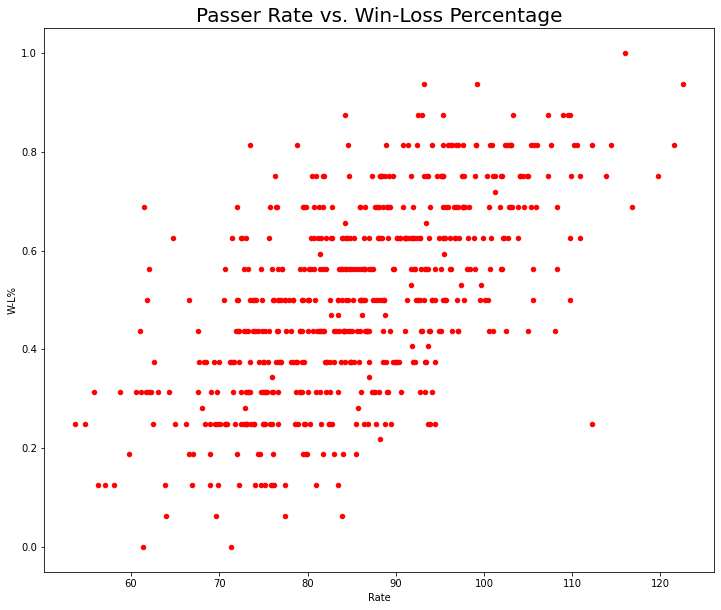

```python
df.plot.scatter(x="Rate", y="W-L%", color="red", figsize=(12, 10))
plt.title('Passer Rate vs. Win-Loss Percentage', fontsize=20)
```

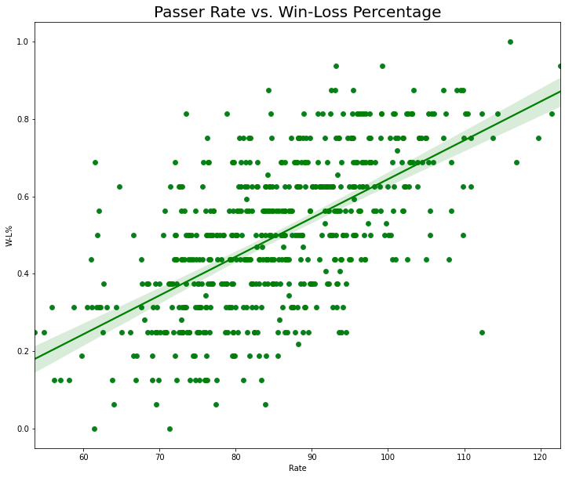

```python
df.plot.scatter(x = 'Rate', y = 'W-L%', figsize=(12, 10))
sns.regplot(x = 'Rate', y = 'W-L%', data = df, color="green")
plt.title('Passer Rate vs. Win-Loss Percentage', fontsize=20)
```

In the regression plot shown above, there is a clear positive linear relationship shown by the the regression line fit to the data. After seeing this, I then examined the same data but for each year instead of all at once.

## By Year

I used subplots from the package matplotlib and regression plots from seaborn in order to visualize all of these plots all at once with the relationship shown on each plot.

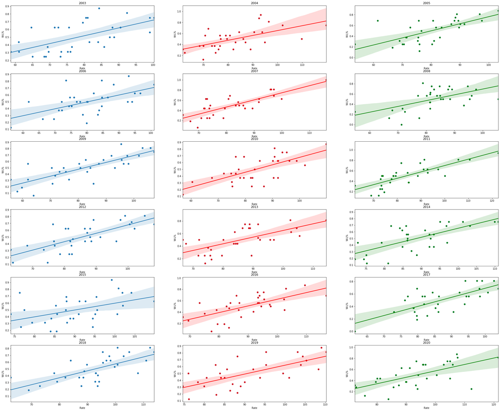

```python
fig, axs = plt.subplots(6, 3, figsize=(36, 30))
axs[0, 0].scatter(x = df2003['Rate'], y = df2003['W-L%'])
sns.regplot(x = 'Rate', y = 'W-L%', data = df2003, ax=axs[0,0])
axs[0, 0].title.set_text('2003')
axs[0, 1].scatter(x = df2004['Rate'], y = df2004['W-L%'])
sns.regplot(x = 'Rate', y = 'W-L%', data = df2004, ax=axs[0,1], color="red")
axs[0, 1].title.set_text('2004')
axs[0, 2].scatter(x = df2005['Rate'], y = df2005['W-L%'])
sns.regplot(x = 'Rate', y = 'W-L%', data = df2005, ax=axs[0,2], color="green")
axs[0, 2].title.set_text('2005')
axs[1, 0].scatter(x = df2006['Rate'], y = df2006['W-L%'])
sns.regplot(x = 'Rate', y = 'W-L%', data = df2006, ax=axs[1,0])
axs[1, 0].title.set_text('2006')
axs[1, 1].scatter(x = df2007['Rate'], y = df2007['W-L%'])
sns.regplot(x = 'Rate', y = 'W-L%', data = df2007, ax=axs[1,1], color="red")
axs[1, 1].title.set_text('2007')
axs[1, 2].scatter(x = df2008['Rate'], y = df2008['W-L%'])
sns.regplot(x = 'Rate', y = 'W-L%', data = df2008, ax=axs[1,2], color="green")
axs[1, 2].title.set_text('2008')
axs[2, 0].scatter(x = df2009['Rate'], y = df2009['W-L%'])
sns.regplot(x = 'Rate', y = 'W-L%', data = df2009, ax=axs[2,0])
axs[2, 0].title.set_text('2009')
axs[2, 1].scatter(x = df2010['Rate'], y = df2010['W-L%'])
sns.regplot(x = 'Rate', y = 'W-L%', data = df2010, ax=axs[2,1], color="red")
axs[2, 1].title.set_text('2010')
axs[2, 2].scatter(x = df2011['Rate'], y = df2011['W-L%'])
sns.regplot(x = 'Rate', y = 'W-L%', data = df2011, ax=axs[2,2], color="green")
axs[2, 2].title.set_text('2011')
axs[3, 0].scatter(x = df2012['Rate'], y = df2012['W-L%'])
sns.regplot(x = 'Rate', y = 'W-L%', data = df2012, ax=axs[3,0])
axs[3, 0].title.set_text('2012')
axs[3, 1].scatter(x = df2013['Rate'], y = df2013['W-L%'])
sns.regplot(x = 'Rate', y = 'W-L%', data = df2013, ax=axs[3,1], color="red")
axs[3, 1].title.set_text('2013')
axs[3, 2].scatter(x = df2014['Rate'], y = df2014['W-L%'])
sns.regplot(x = 'Rate', y = 'W-L%', data = df2014, ax=axs[3,2], color="green")
axs[3, 2].title.set_text('2014')
axs[4, 0].scatter(x = df2015['Rate'], y = df2015['W-L%'])
sns.regplot(x = 'Rate', y = 'W-L%', data = df2015, ax=axs[4,0])
axs[4, 0].title.set_text('2015')
axs[4, 1].scatter(x = df2016['Rate'], y = df2016['W-L%'])
sns.regplot(x = 'Rate', y = 'W-L%', data = df2016, ax=axs[4,1], color="red")
axs[4, 1].title.set_text('2016')
axs[4, 2].scatter(x = df2017['Rate'], y = df2017['W-L%'])
sns.regplot(x = 'Rate', y = 'W-L%', data = df2017, ax=axs[4,2], color="green")
axs[4, 2].title.set_text('2017')
axs[5, 0].scatter(x = df2018['Rate'], y = df2018['W-L%'])
sns.regplot(x = 'Rate', y = 'W-L%', data = df2018, ax=axs[5,0])
axs[5, 0].title.set_text('2018')
axs[5, 1].scatter(x = df2019['Rate'], y = df2019['W-L%'])
sns.regplot(x = 'Rate', y = 'W-L%', data = df2019, ax=axs[5,1], color="red")
axs[5, 1].title.set_text('2019')
axs[5, 2].scatter(x = df2020['Rate'], y = df2020['W-L%'])
sns.regplot(x = 'Rate', y = 'W-L%', data = df2020, ax=axs[5,2], color="green")
axs[5, 2].title.set_text('2020')
```

It is clear from visualizing the plots for each year that there is a positive linear relationship between passer rate and win loss percentage in each year. There are outliers present in some of the years but in general it is clear that a better passer rating leads to a higher win-loss percentage.

## By Team

I next decided to do the same but for each team instead of each year in order to see if each team also had a positive relationship for passer rating and win-loss percentage. I started by first making dataframes for each of the teams taking rows from the main dataframe.

```python
ATL = df[df.Team == 'Atlanta Falcons']
CHI = df[df.Team == 'Chicago Bears']
DET = df[df.Team == 'Detroit Lions']
BAL = df[df.Team == 'Baltimore Ravens']
OAK = df[df.Team == 'Oakland Raiders']
NYG = df[df.Team == 'New York Giants']
ARI = df[df.Team == 'Arizona Cardinals']
BUF = df[df.Team == 'Buffalo Bills']
HOU = df[df.Team == 'Houston Texans']
DAL = df[df.Team == 'Dallas Cowboys']
MIA = df[df.Team == 'Miami Dolphins']
SD = df[df.Team == 'San Diego Chargers']
WAS = df[df.Team == 'Washington Redskins']
CLE = df[df.Team == 'Cleveland Browns']
DEN = df[df.Team == 'Denver Broncos']
JAX = df[df.Team == 'Jacksonville Jaguars']
PIT = df[df.Team == 'Pittsburgh Steelers']
CAR = df[df.Team == 'Carolina Panthers']
PHI = df[df.Team == 'Philadelphia Eagles']
STL = df[df.Team == 'St. Louis Rams']
TB = df[df.Team == 'Tampa Bay Buccaneers']
SF = df[df.Team == 'San Francisco 49ers']
NE = df[df.Team == 'New England Patriots']
NYJ = df[df.Team == 'New York Jets']
CIN = df[df.Team == 'Cincinnati Bengals']
SEA = df[df.Team == 'Seattle Seahawks']
NO = df[df.Team == 'New Orleans Saints']
GB = df[df.Team == 'Green Bay Packers']
KC = df[df.Team == 'Kansas City Chiefs']
MIN = df[df.Team == 'Minnesota Vikings']
IND = df[df.Team == 'Indianapolis Colts']
TEN = df[df.Team == 'Tennessee Titans']
```

## AFC

I then created subplots for the entire AFC with each row of plots being a division and I color-coded the regression plots by the team's color.

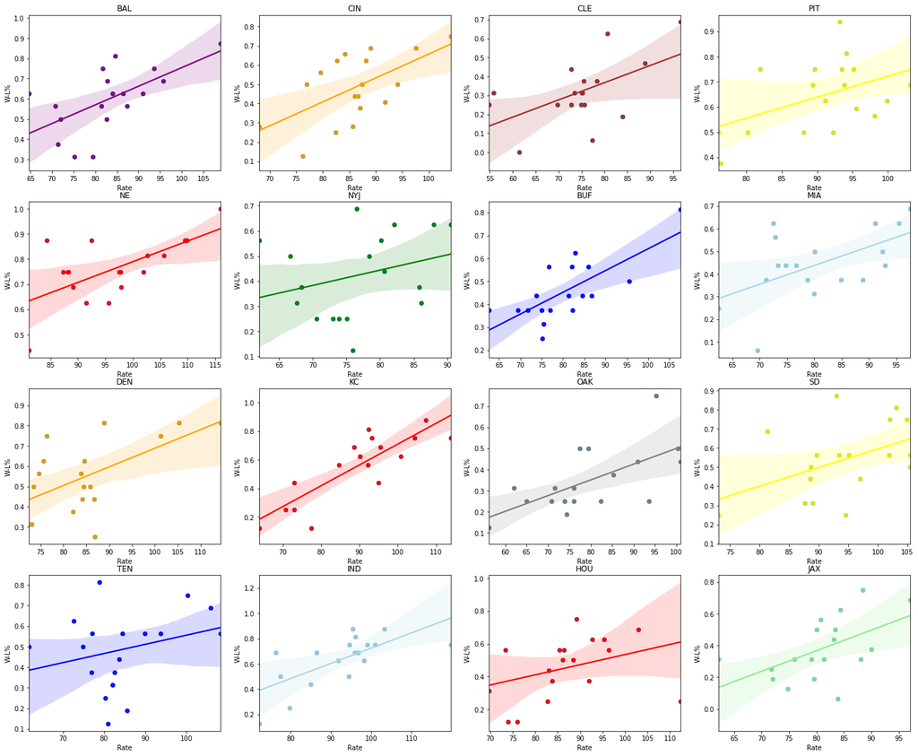

```python
fig, axs = plt.subplots(4, 4, figsize=(24, 20))
axs[0, 0].scatter(x = BAL['Rate'], y = BAL['W-L%'])
sns.regplot(x = 'Rate', y = 'W-L%', data = BAL, ax=axs[0,0], color="purple")
axs[0, 0].title.set_text('BAL')
axs[0, 1].scatter(x = CIN['Rate'], y = CIN['W-L%'])
sns.regplot(x = 'Rate', y = 'W-L%', data = CIN, ax=axs[0,1], color="orange")
axs[0, 1].title.set_text('CIN')
axs[0, 2].scatter(x = CLE['Rate'], y = CLE['W-L%'])
sns.regplot(x = 'Rate', y = 'W-L%', data = CLE, ax=axs[0,2], color="brown")
axs[0, 2].title.set_text('CLE')
axs[0, 3].scatter(x = PIT['Rate'], y = PIT['W-L%'])
sns.regplot(x = 'Rate', y = 'W-L%', data = PIT, ax=axs[0,3], color="yellow")
axs[0, 3].title.set_text('PIT')
axs[1, 0].scatter(x = NE['Rate'], y = NE['W-L%'])
sns.regplot(x = 'Rate', y = 'W-L%', data = NE, ax=axs[1,0], color="red")
axs[1, 0].title.set_text('NE')
axs[1, 1].scatter(x = NYJ['Rate'], y = NYJ['W-L%'])
sns.regplot(x = 'Rate', y = 'W-L%', data = NYJ, ax=axs[1,1], color="green")
axs[1, 1].title.set_text('NYJ')
axs[1, 2].scatter(x = BUF['Rate'], y = BUF['W-L%'])
sns.regplot(x = 'Rate', y = 'W-L%', data = BUF, ax=axs[1,2], color="blue")
axs[1, 2].title.set_text('BUF')
axs[1, 3].scatter(x = MIA['Rate'], y = MIA['W-L%'])
sns.regplot(x = 'Rate', y = 'W-L%', data = MIA, ax=axs[1,3], color="lightblue")
axs[1, 3].title.set_text('MIA')
axs[2, 0].scatter(x = DEN['Rate'], y = DEN['W-L%'])
sns.regplot(x = 'Rate', y = 'W-L%', data = DEN, ax=axs[2,0], color="orange")
axs[2, 0].title.set_text('DEN')
axs[2, 1].scatter(x = KC['Rate'], y = KC['W-L%'])
sns.regplot(x = 'Rate', y = 'W-L%', data = KC, ax=axs[2,1], color="red")
axs[2, 1].title.set_text('KC')
axs[2, 2].scatter(x = OAK['Rate'], y = OAK['W-L%'])
sns.regplot(x = 'Rate', y = 'W-L%', data = OAK, ax=axs[2,2], color="grey")
axs[2, 2].title.set_text('OAK')
axs[2, 3].scatter(x = SD['Rate'], y = SD['W-L%'])
sns.regplot(x = 'Rate', y = 'W-L%', data = SD, ax=axs[2,3], color="yellow")
axs[2, 3].title.set_text('SD')
axs[3, 0].scatter(x = TEN['Rate'], y = TEN['W-L%'])
sns.regplot(x = 'Rate', y = 'W-L%', data = TEN, ax=axs[3,0], color="blue")
axs[3, 0].title.set_text('TEN')
axs[3, 1].scatter(x = IND['Rate'], y = IND['W-L%'])
sns.regplot(x = 'Rate', y = 'W-L%', data = IND, ax=axs[3,1], color="lightblue")
axs[3, 1].title.set_text('IND')
axs[3, 2].scatter(x = HOU['Rate'], y = HOU['W-L%'])
sns.regplot(x = 'Rate', y = 'W-L%', data = HOU, ax=axs[3,2], color="red")
axs[3, 2].title.set_text('HOU')
axs[3, 3].scatter(x = JAX['Rate'], y = JAX['W-L%'])
sns.regplot(x = 'Rate', y = 'W-L%', data = JAX, ax=axs[3,3], color="lightgreen")
axs[3, 3].title.set_text('JAX')
```

## NFC

I then created subplots for the entire NFC with each row of plots being a division and I color-coded the regression plots by the team's color.

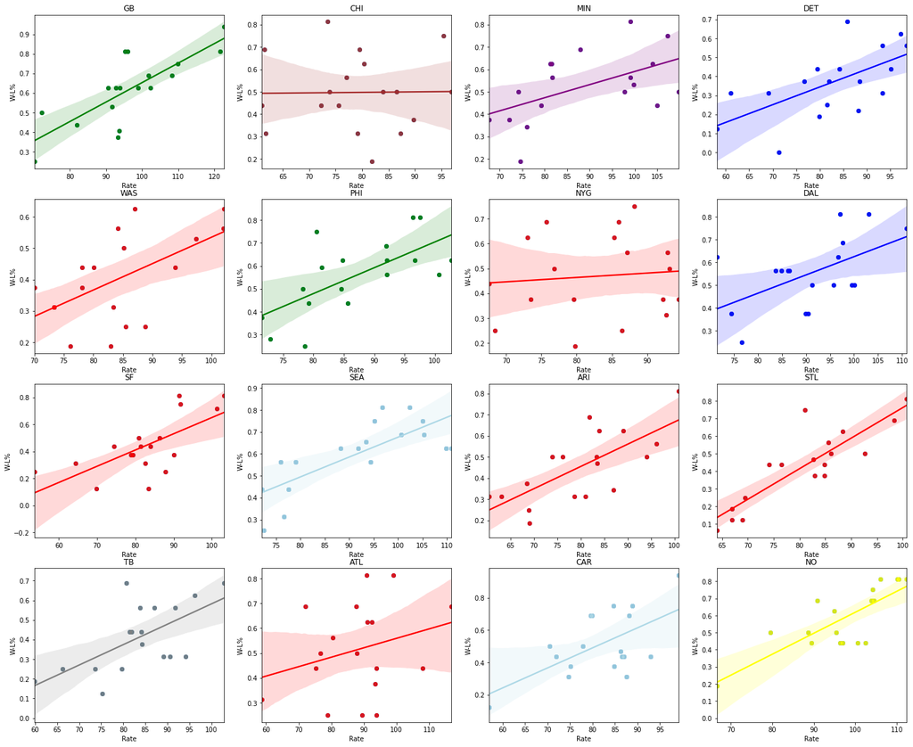

```python
fig, axs = plt.subplots(4, 4, figsize=(24, 20))
axs[0, 0].scatter(x = GB['Rate'], y = GB['W-L%'])
sns.regplot(x = 'Rate', y = 'W-L%', data = GB, ax=axs[0,0], color="green")
axs[0, 0].title.set_text('GB')
axs[0, 1].scatter(x = CHI['Rate'], y = CHI['W-L%'])
sns.regplot(x = 'Rate', y = 'W-L%', data = CHI, ax=axs[0,1], color="brown")
axs[0, 1].title.set_text('CHI')
axs[0, 2].scatter(x = MIN['Rate'], y = MIN['W-L%'])
sns.regplot(x = 'Rate', y = 'W-L%', data = MIN, ax=axs[0,2], color="purple")
axs[0, 2].title.set_text('MIN')
axs[0, 3].scatter(x = DET['Rate'], y = DET['W-L%'])
sns.regplot(x = 'Rate', y = 'W-L%', data = DET, ax=axs[0,3], color="blue")
axs[0, 3].title.set_text('DET')
axs[1, 0].scatter(x = WAS['Rate'], y = WAS['W-L%'])
sns.regplot(x = 'Rate', y = 'W-L%', data = WAS, ax=axs[1,0], color="red")
axs[1, 0].title.set_text('WAS')
axs[1, 1].scatter(x = PHI['Rate'], y = PHI['W-L%'])
sns.regplot(x = 'Rate', y = 'W-L%', data = PHI, ax=axs[1,1], color="green")
axs[1, 1].title.set_text('PHI')
axs[1, 2].scatter(x = NYG['Rate'], y = NYG['W-L%'])
sns.regplot(x = 'Rate', y = 'W-L%', data = NYG, ax=axs[1,2], color="red")
axs[1, 2].title.set_text('NYG')
axs[1, 3].scatter(x = DAL['Rate'], y = DAL['W-L%'])
sns.regplot(x = 'Rate', y = 'W-L%', data = DAL, ax=axs[1,3], color="blue")
axs[1, 3].title.set_text('DAL')
axs[2, 0].scatter(x = SF['Rate'], y = SF['W-L%'])
sns.regplot(x = 'Rate', y = 'W-L%', data = SF, ax=axs[2,0], color="red")
axs[2, 0].title.set_text('SF')
axs[2, 1].scatter(x = SEA['Rate'], y = SEA['W-L%'])
sns.regplot(x = 'Rate', y = 'W-L%', data = SEA, ax=axs[2,1], color="lightblue")
axs[2, 1].title.set_text('SEA')
axs[2, 2].scatter(x = ARI['Rate'], y = ARI['W-L%'])
sns.regplot(x = 'Rate', y = 'W-L%', data = ARI, ax=axs[2,2], color="red")
axs[2, 2].title.set_text('ARI')
axs[2, 3].scatter(x = STL['Rate'], y = STL['W-L%'])
sns.regplot(x = 'Rate', y = 'W-L%', data = STL, ax=axs[2,3], color="red")
axs[2, 3].title.set_text('STL')
axs[3, 0].scatter(x = TB['Rate'], y = TB['W-L%'])
sns.regplot(x = 'Rate', y = 'W-L%', data = TB, ax=axs[3,0], color="grey")
axs[3, 0].title.set_text('TB')
axs[3, 1].scatter(x = ATL['Rate'], y = ATL['W-L%'])
sns.regplot(x = 'Rate', y = 'W-L%', data = ATL, ax=axs[3,1], color="red")
axs[3, 1].title.set_text('ATL')
axs[3, 2].scatter(x = CAR['Rate'], y = CAR['W-L%'])
sns.regplot(x = 'Rate', y = 'W-L%', data = CAR, ax=axs[3,2], color="lightblue")
axs[3, 2].title.set_text('CAR')
axs[3, 3].scatter(x = NO['Rate'], y = NO['W-L%'])
sns.regplot(x = 'Rate', y = 'W-L%', data = NO, ax=axs[3,3], color="yellow")
axs[3, 3].title.set_text('NO')
```

# Machine Learning

Next, I used robust scaler and label encoder in the preprocessing package of sklearn to turn the categorical data into numbers starting at 0, and to remove the median and scale the data according to the IQR for the passer rate and win-loss percentage. I also dropped the columns not necessary for machine learning and set X to be the dataframe with just Team, Year and Rate standardized while y is just the win-loss percentage of every row in an array.

```python
X = df
rc = RobustScaler()
numerical = ['W-L%', 'Rate']
X[numerical] = rc.fit_transform(X[numerical])
y = df['W-L%']
X = X.drop(columns=['W', 'L', 'T', 'W-L%'])
le = sklearn.preprocessing.LabelEncoder()
X['Team'] = le.fit_transform(X['Team'])
X['Year'] = le.fit_transform(X['Year'])
```

## Splitting the data

I split the data into a training set and a testing set in order to train the method on the training set and test it on the testing set to see the accuracy.

```python
from sklearn.model_selection import train_test_split

X_train, X_test, y_train, y_test = train_test_split(X, y, test_size = 0.3, random_state = 12)
X_train.shape, y_train.shape, X_test.shape, y_test.shape
```

```
((403, 3), (403,), (173, 3), (173,))
```

## Linear Regression

Linear regression, or ordinary least squares (OLS) finds the parameters w and b that minimize the mean squared error between predictions and the true regression targets, y, on the training set.

```python
# instantiate the model
lr = LinearRegression()
# fit the model
lr.fit(X_train, y_train)

#predicting the target value from the model for the samples
y_test_lr = lr.predict(X_test)
y_train_lr = lr.predict(X_train)

#computing the accuracy of the model performance
acc_train_lr = lr.score(X_train, y_train)
acc_test_lr = lr.score(X_test, y_test)

#computing root mean squared error (RMSE)
rmse_train_lr = np.sqrt(mean_squared_error(y_train, y_train_lr))
rmse_test_lr = np.sqrt(mean_squared_error(y_test, y_test_lr))

print("Linear Regression: Accuracy on training Data: {:.3f}".format(acc_train_lr))
print("Linear Regression: Accuracy on test Data: {:.3f}".format(acc_test_lr))
print('\nLinear Regression: The RMSE of the training set is:', rmse_train_lr)
print('Linear Regression: The RMSE of the testing set is:', rmse_test_lr)
```

```
Linear Regression: Accuracy on training Data: 0.477
Linear Regression: Accuracy on test Data: 0.346

Linear Regression: The RMSE of the training set is: 0.5692084409865641
Linear Regression: The RMSE of the testing set is: 0.6143137242293805
```

The accuracy on the training Data and test Data are just 0.477 and 0.346. Therefore, the performance of this model is not as well as you would hope. Below, I plotted the residuals to show the differences between the predicted and actual win-loss percentage on the training data, with the center being a difference of 0.

```
0.476803736656348
```

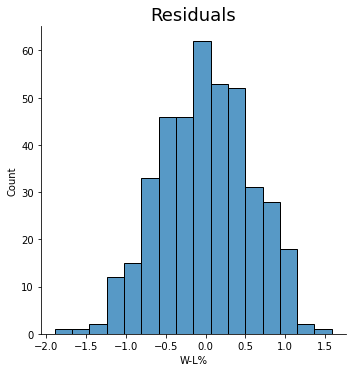

```python
y_hat = lr.predict(X_train)
sns.displot(y_train - y_hat)
plt.title("Residuals", size=18)
lr.score(X_train,y_train)
```

## SVM Regression

The objective of SVR is to consider the points that are within the decision boundary line. The best fit line is the hyperplane that has a maximum number of points.

```python
sc_X = StandardScaler()
sc_y = StandardScaler()
X = sc_X.fit_transform(X)
y = sc_y.fit_transform(pd.DataFrame(y))
# instantiate the model
clf = SVR(kernel = 'rbf')
# fit the model
clf.fit(X_train, y_train)

#predicting the target value from the model for the samples
y_test_clf = clf.predict(X_test)
y_train_clf = clf.predict(X_train)

#computing the accuracy of the model performance
acc_train_clf = clf.score(X_train, y_train)
acc_test_clf = clf.score(X_test, y_test)

#computing root mean squared error (RMSE)
rmse_train_clf = np.sqrt(mean_squared_error(y_train, y_train_clf))
rmse_test_clf = np.sqrt(mean_squared_error(y_test, y_test_clf))

print("SVM Regression: Accuracy on training Data: {:.3f}".format(acc_train_clf))
print("SVM Regression: Accuracy on test Data: {:.3f}".format(acc_test_clf))
print('\nSVM Regression: The RMSE of the training set is:', rmse_train_clf)
print('SVM Regression: The RMSE of the testing set is:', rmse_test_clf)
```

```
SVM Regression: Accuracy on training Data: 0.399
SVM Regression: Accuracy on test Data: 0.215

SVM Regression: The RMSE of the training set is: 0.6099252787360319
SVM Regression: The RMSE of the testing set is: 0.673135614423326
```

The accuracy on the training Data and test Data are just 0.399 and 0.215. Therefore, the performance of this model is not as well as you would hope. Below, I plotted the residuals to show the differences between the predicted and actual win-loss percentage on the training data, with the center being a difference of 0.

```
0.3992756491845988
```

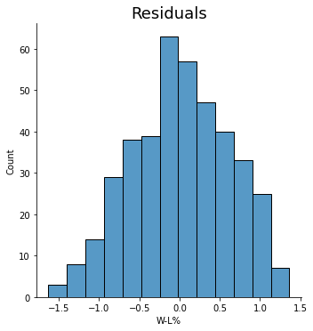

```python
y_hat = clf.predict(X_train)
sns.displot(y_train - y_hat)
plt.title("Residuals", size=18)
clf.score(X_train,y_train)
```

A good place to find more info about SVM in python would be: https://www.analyticsvidhya.com/blog/2020/03/support-vector-regression-tutorial-for-machine-learning/

A good spot for linear regression if you want to learn more would also be: https://realpython.com/linear-regression-in-python/

This is the end of my analysis of passer rating vs. win-loss percentage, thank you for taking the time to look through it!